# Kirk McGraw Quant Project

Quantitative Finance Model by Kirk McGraw  
The goal of this project is to build a quantitative trading algorithm using industry techniques as well as methods discussed in Harvard's CSCI - 278 Applied Quantitative Finance. I've decided to implement a pairs trading mean-reversion strategy, where we can indentify cointegrated pairs of stocks which are currently experiencing a temporary deviation, measured with a z-score. We can then short or go long on the stock based on the direction of the z-score, and exit the trade when the stock pair reverts to its historical cointegration. This strategy has multiple caveats and risks, some of which are foundational, such as a fundemental breakdown in cointegration of a pair, but others can be mitigated, such as by using market beta to hedge our risk. To start, we'll engineer some technical features to use as essential market indicators that allow our model to get a grasp of the state of the S&P500's volatility and returns, amongst others. Not every feature will be used in the full analysis, but they offer additional avenues for exploration and alternative model parameters.

```python
import yfinance as yf
import pandas as pd
import numpy as np
from IPython.display import display
from datetime import timedelta
import matplotlib.pyplot as plt

def create_technical_features(tickers=pd.read_html('https://en.wikipedia.org/wiki/List_of_S%26P_500_companies')[0],
                              start_date="2015-06-01",
                              end_date="2025-06-01",
                              ma_windows=[5, 20, 50],
                              ema_windows=[20, 50],
                              rsi_window=14,
                              beta_window = 50):
    """
    Downloads stock data and engineers a variety of technical features.

    Args:
        tickers: A list of stock tickers to download from Yahoo Finance.
        start_date: The start date for the data in 'YYYY-MM-DD'.
        end_date: The end date for the data in 'YYYY-MM-DD'.
        ma_windows: A list of window lengths for simple moving averages.
        ema_windows: A list of window lengths for calculating the exponential moving average.
        rsi_window: The window for the computing the Relative Strength Index (RSI).
        beta_window: The window for calculating the stock beta

    Returns:
        A DataFrame of stock features, indexed by Date and Ticker for easy of use.
    """

    longest_window = max(ma_windows + ema_windows + [rsi_window, 26, 12]) # MACD uses 26 and 12
    warmup_days = longest_window + 60 # Add a buffer
    fetch_start_date = (pd.to_datetime(start_date) - timedelta(days=warmup_days)).strftime('%Y-%m-%d')

    print(f"Longest window is {longest_window} days. Fetching data from {fetch_start_date}")
    spy = pd.DataFrame({'Symbol':['SPY']})
    tickers = pd.concat([tickers,spy])
    stock_data = yf.download(tickers['Symbol'].tolist(), start=fetch_start_date, end=end_date, progress=False)

    data = stock_data.stack(level=1).rename_axis(['Date', 'Ticker']) # Rename axis for clarity
    features = pd.DataFrame(index=data.index)

    print("Creating price and volume features")
    features['intraday_return'] = data['Close'] / data['Open'] - 1
    features['overnight_gap'] = data['Open'] / data.groupby(level='Ticker')['Close'].shift(1) - 1
    # Use log1p if volume is 0
    features['log_volume'] = data.groupby(level='Ticker')['Volume'].transform(lambda x: np.log1p(x))

    print("Creating moving average features")
    for window in ma_windows:
        features[f'vol_ma_{window}'] = data.groupby(level='Ticker')['Volume'].transform(lambda x: x.rolling(window).mean())
        features[f'close_ma_{window}'] = data.groupby(level='Ticker')['Close'].transform(lambda x: x.rolling(window).mean())
        features[f'price_vs_ma_{window}'] = data['Close'] / features[f'close_ma_{window}'] - 1

    for window in ema_windows:
        features[f'close_ema_{window}'] = data.groupby(level='Ticker')['Close'].transform(lambda x: x.ewm(span=window, adjust=False).mean())
        features[f'price_vs_ema_{window}'] = data['Close'] / features[f'close_ema_{window}'] - 1

    print("Creating volatility and oscillator features")
    high_low = data['High'] - data['Low']
    high_prev_close = np.abs(data['High'] - data.groupby(level='Ticker')['Close'].shift(1))
    low_prev_close = np.abs(data['Low'] - data.groupby(level='Ticker')['Close'].shift(1))

    #Calculate the ATR using an exponential moving average to improve recent information's impact on the metric
    true_range = pd.concat([high_low, high_prev_close, low_prev_close], axis=1).max(axis=1)
    features['atr'] = true_range.groupby(level='Ticker').transform(lambda x: x.ewm(span=window, adjust=False).mean())

    print("Calculating rolling beta against SPY")
    returns = data['Close'].unstack().pct_change()
    market_returns = returns['SPY']
    #calculate beta for a single stock's returns
    def calculate_rolling_beta(stock_returns, market_returns, window):
        #calculate rolling covariance between a stock and the market
        rolling_cov = stock_returns.rolling(window=window).cov(market_returns)
        #calculate rolling variance
        rolling_var = market_returns.rolling(window=window).var()

        return rolling_cov / rolling_var

    #Apply the function to each stock, but dont forget to exclude SPY
    beta_series = returns.drop('SPY', axis=1).apply(lambda x: calculate_rolling_beta(x, market_returns, beta_window))

    #Stack to match the features DataFrame's index
    features['beta'] = beta_series.stack()

    #Relative Strength Index, RSI
    def rsi(close, window):
        delta = close.diff()
        gain = (delta.where(delta > 0, 0)).ewm(alpha=1/window, adjust=False).mean() # Smoothed
        loss = (-delta.where(delta < 0, 0)).ewm(alpha=1/window, adjust=False).mean()
        rs = gain / loss
        return 100 - (100 / (1 + rs))

    features['rsi'] = data.groupby(level='Ticker')['Close'].transform(lambda x: rsi(x, rsi_window))


    #Moving Average Convergence Divergence (MACD)
    def macd(close):
        ema_12 = close.ewm(span=12, adjust=False).mean()
        ema_26 = close.ewm(span=26, adjust=False).mean()
        return ema_12 - ema_26

    features['macd'] = data.groupby(level='Ticker')['Close'].transform(macd)
    features['macd_signal'] = features.groupby(level='Ticker')['macd'].transform(lambda x: x.ewm(span=9, adjust=False).mean())

    features = features.drop('SPY', level='Ticker', errors='ignore')
    features = features.dropna(how='all')
    print("Feature engineering finished.")

    return features.loc[start_date:]

technical_features = create_technical_features()
print("\nGenerated features dataframe:")
display(technical_features.tail())
print("\nExample dataframe of one ticker:")
display(technical_features.loc[(slice(None), 'NVDA'), :].head())
```

```
Longest window is 50 days. Fetching data from 2015-02-11
```

```
Creating price and volume features
Creating moving average features
Creating volatility and oscillator features
Calculating rolling beta against SPY
Feature engineering finished.

Generated features dataframe:
```

| Date | Ticker | intraday_return | overnight_gap | log_volume | vol_ma_5 | close_ma_5 | price_vs_ma_5 | vol_ma_20 | close_ma_20 | price_vs_ma_20 | vol_ma_50 | ... | price_vs_ma_50 | close_ema_20 | price_vs_ema_20 | close_ema_50 | price_vs_ema_50 | atr | beta | rsi | macd | macd_signal |
| --- | --- | --- | --- | --- | --- | --- | --- | --- | --- | --- | --- | --- | --- | --- | --- | --- | --- | --- | --- | --- | --- | --- |
| 2025-05-30 | XYZ | 0.000486 | -0.007078 | 16.256709 | 9460220.0 | 61.322001 | 0.006980 | 13996565.0 | 55.565500 | 0.111301 | 10588088.0 | ... | 0.105399 | 57.871444 | 0.067020 | 58.543680 | 0.054768 | 2.891990 | 1.300048 | 61.045201 | 1.696999 | 0.857835 |
|  | YUM | -0.000694 | 0.000000 | 14.973775 | 2004600.0 | 143.991998 | -0.000361 | 1838925.0 | 146.058117 | -0.014502 | 2302796.0 | ... | -0.027595 | 145.654768 | -0.011773 | 146.527114 | -0.017656 | 2.879334 | 0.379498 | 43.000200 | -0.935830 | -0.703460 |
|  | ZBH | -0.008285 | -0.004285 | 15.069758 | 2731520.0 | 92.689636 | -0.008178 | 3082335.0 | 94.478996 | -0.026963 | 2449406.0 | ... | -0.086578 | 94.945031 | -0.031739 | 98.713336 | -0.068701 | 2.733337 | 0.349883 | 39.438192 | -2.164977 | -2.181889 |
|  | ZBRA | -0.000552 | -0.008786 | 13.394070 | 444180.0 | 290.457996 | -0.002369 | 581725.0 | 283.547498 | 0.021945 | 684846.0 | ... | 0.096115 | 282.861863 | 0.024422 | 279.868064 | 0.035381 | 10.182748 | 1.672413 | 57.538800 | 8.824800 | 9.284781 |
|  | ZTS | 0.010244 | -0.001316 | 15.514387 | 2939440.0 | 165.448767 | 0.015831 | 3276110.0 | 160.661278 | 0.046102 | 2950692.0 | ... | 0.071416 | 161.316085 | 0.041855 | 159.492603 | 0.053767 | 4.290751 | 0.696194 | 63.200201 | 2.886123 | 2.149763 |

5 rows × 21 columns

```
Example dataframe of one ticker:
```

| Date | Ticker | intraday_return | overnight_gap | log_volume | vol_ma_5 | close_ma_5 | price_vs_ma_5 | vol_ma_20 | close_ma_20 | price_vs_ma_20 | vol_ma_50 | ... | price_vs_ma_50 | close_ema_20 | price_vs_ema_20 | close_ema_50 | price_vs_ema_50 | atr | beta | rsi | macd | macd_signal |
| --- | --- | --- | --- | --- | --- | --- | --- | --- | --- | --- | --- | --- | --- | --- | --- | --- | --- | --- | --- | --- | --- | --- |
| 2015-06-01 | NVDA | 0.004939 | 0.006326 | 19.736177 | 345509600.0 | 0.528651 | 0.024538 | 359851400.0 | 0.518258 | 0.045084 | 322590240.0 | ... | 0.029381 | 0.522126 | 0.037342 | 0.524375 | 0.032893 | 0.011786 | 1.183094 | 61.436413 | 0.000310 | -0.003761 |
| 2015-06-02 | NVDA | -0.013489 | -0.006256 | 19.228513 | 338424000.0 | 0.534508 | -0.006611 | 361030600.0 | 0.517573 | 0.025892 | 317834640.0 | ... | 0.010464 | 0.522968 | 0.015309 | 0.524634 | 0.012086 | 0.011761 | 1.188037 | 54.395254 | 0.000923 | -0.002824 |
| 2015-06-03 | NVDA | -0.013636 | 0.002735 | 19.340119 | 302115200.0 | 0.533830 | -0.016230 | 358923600.0 | 0.517297 | 0.015212 | 314330160.0 | ... | 0.000245 | 0.523178 | 0.003801 | 0.524655 | 0.000975 | 0.011783 | 1.139949 | 50.964346 | 0.000929 | -0.002074 |
| 2015-06-04 | NVDA | 0.024108 | -0.005991 | 19.595365 | 301326400.0 | 0.533588 | 0.001905 | 359285000.0 | 0.517408 | 0.033236 | 314194800.0 | ... | 0.018416 | 0.524266 | 0.019720 | 0.525045 | 0.018208 | 0.011881 | 0.998495 | 55.838945 | 0.001677 | -0.001323 |
| 2015-06-05 | NVDA | 0.010899 | -0.003169 | 19.562736 | 296956800.0 | 0.534217 | 0.008426 | 348222800.0 | 0.517255 | 0.041496 | 309610160.0 | ... | 0.025008 | 0.525642 | 0.024877 | 0.525581 | 0.024997 | 0.011956 | 0.596188 | 57.807817 | 0.002571 | -0.000545 |

5 rows × 21 columns

The technical features appear to be computing as expected, so now we'll move on to exploring cointegrated pairs. We'll use the tried and true Engle-Granger two-step cointegration test from statsmodels for this function. This function actually explores every stock in our features list, giving it a fairly expensive computational cost of 466(466-1)/2 = 108,345 tests. This is definitely overkill, but allows us to sort the final output and find the most significantly cointegrated pairs. This will give us plenty of options to choose from when creating the pairs trading model. As an aside, the reason we only have 466 stocks in our "S&P500" is due to using wikipedia's list of S&P500 companies, which only includes current companies. If a company isn't in the data from the full start and end date time window (10 years in this case), it won't be included in our basket. This should be okay, though, as we still have plenty of companies to compare.

```python
from statsmodels.tsa.stattools import coint

def find_cointegrated_pairs(features_df, price_series='close_ma_20', p_value_threshold=0.001):
    """
    Finds cointegrated pairs of stocks from a large features DataFrame.

    Returns:
        A DataFrame with cointegrated pairs of stocks.
    """
    print("Preparing data for full cointegration analysis")
    log_prices = np.log(features_df[price_series])
    wide_log_prices = log_prices.unstack(level='Ticker').dropna(axis=1)

    tickers = wide_log_prices.columns
    n_tickers = len(tickers)
    print(f"Analyzing {n_tickers} tickers, which requires {n_tickers * (n_tickers - 1) // 2:,} pair tests.")

    results = []

    for i in range(n_tickers):
        for j in range(i + 1, n_tickers):
            series1 = wide_log_prices[tickers[i]]
            series2 = wide_log_prices[tickers[j]]

            p_value = coint(series1, series2)[1]

            if p_value < p_value_threshold:
                results.append({
                    'Ticker 1': tickers[i],
                    'Ticker 2': tickers[j],
                    'P-Value': p_value
                })

    print(f"\nAnalysis complete")

    if not results:
        print("No cointegrated pairs found")
        return pd.DataFrame()

    return pd.DataFrame(results).sort_values('P-Value')


#Run the cointegration analysis on the full S&P
all_significant_pairs = find_cointegrated_pairs(technical_features)

print(f"\nFound {len(all_significant_pairs)} cointegrated pairs")
print("Top 10 most significant pairs:")
display(all_significant_pairs.head(10))
```

```
Preparing data for full cointegration analysis
Analyzing 466 tickers, which requires 108,345 pair tests.

Analysis complete

Found 494 cointegrated pairs
Top 10 most significant pairs:
```

|  | Ticker 1 | Ticker 2 | P-Value |
| --- | --- | --- | --- |
| 302 | GRMN | ICE | 3.237443e-07 |
| 150 | CDNS | LIN | 3.904729e-07 |
| 407 | LOW | MPWR | 2.483632e-06 |
| 200 | DOV | HD | 3.126613e-06 |
| 76 | AMGN | DECK | 3.210139e-06 |
| 176 | CMI | TMUS | 4.510968e-06 |
| 344 | HSIC | SJM | 4.926934e-06 |
| 85 | AMGN | PGR | 6.002242e-06 |
| 396 | KO | WRB | 6.307976e-06 |
| 387 | KMX | MDT | 7.438441e-06 |

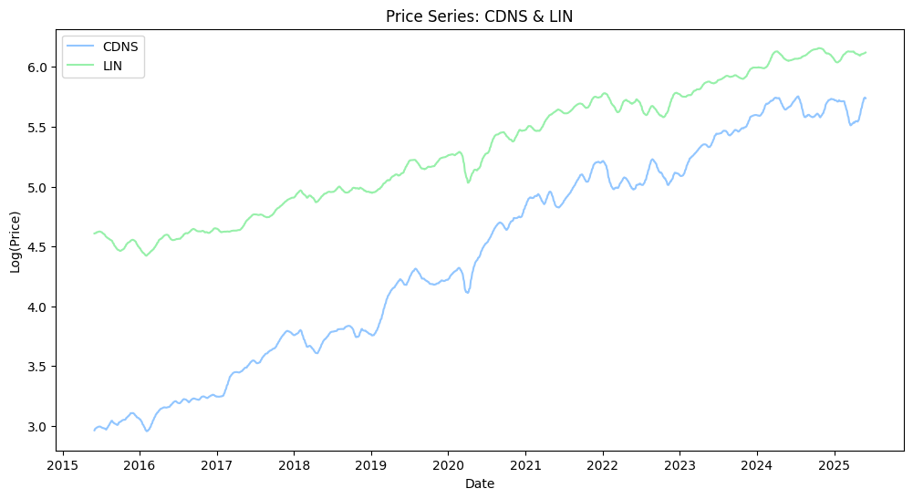

```python
def plot_pair(features_df, ticker1, ticker2, price_series='close_ma_20'):
    """
    Plots the log-price series for a specific pair of tickers.
    """
    log_prices = np.log(features_df[price_series])
    pair_prices = log_prices.loc[(slice(None), [ticker1, ticker2])].unstack(level='Ticker')

    plt.style.use('seaborn-v0_8-pastel')
    fig, ax = plt.subplots(figsize=(12, 6))
    ax.plot(pair_prices.index, pair_prices[ticker1], label=ticker1)
    ax.plot(pair_prices.index, pair_prices[ticker2], label=ticker2)
    ax.set_title(f'Price Series: {ticker1} & {ticker2}')
    ax.set_xlabel('Date')
    ax.set_ylabel('Log(Price)')
    ax.legend()
    plt.show()
top_pair = all_significant_pairs.iloc[1]
plot_pair(technical_features, top_pair['Ticker 1'], top_pair['Ticker 2'])
```

I opted to use 20 day simple moving average close as our price series, as it appears to be a fairly popular metric. We can see from the plot above that our analysis was successful in indentifying cointegrated pairs across the last decade. Next we'll want to caclulated the z-score and spread for our chosen stock pair, so that we can determine when to enter and exit the trade. The z-score spread is a form of standardization that avoids too much weight being placed on larger stocks by scaling them to a common feature. The hedge ratio was also found as an essential tool for determining what ratio of long/short stocks to purchase. There are some essential tests we'll want to run as well, like the Breusch-Pagan which tests for Heteroscedasticity of the variance, a core assumption of linear regression. This is necessary not only because we are running a linear regression to determine the hedge ratio, but also because we will be doing additional logistic regression later to determine when to enter the trade. Finally, we'll run an Augmented Dicky Fuller Test on the z-score spread to ensure our cointegrated pair is stationary. This is an assumption of the mean-reversion strategy we are implementing, as non-stationary series may not revert to the mean. Without a long-term equilibrium, the entire strategy is likely invalid.

```python
import statsmodels.api as sm
from statsmodels.stats.diagnostic import het_breuschpagan
from statsmodels.tsa.stattools import adfuller


def calculate_spread_zscore(features_df, ticker1, ticker2, window=21):
    """
    Calculates the hedge ratio, spread, and z-score for a stock pair,
    and tests for heteroscedasticity and stationarity in the regression residuals.

    Args:
        features_df: The main features DataFrame.
        ticker1: The first ticker (independent variable, X).
        ticker2: The second ticker (dependent variable, Y).
        window: The rolling window for calculating the z-score.

    Returns:
        A DataFrame with log prices, spread, and z-score.
    """
    #find the log-prices for the pair
    df = np.log(features_df.loc[(slice(None), [ticker1, ticker2]), 'close_ma_20']).unstack()
    df = df.dropna()

    #Calculate hedge ratio using an linear regression
    X = sm.add_constant(df[ticker1])
    model = sm.OLS(df[ticker2], X).fit()
    hedge_ratio = model.params[1]

    print(f'Cointegrated Stock Pair: {ticker1} vs {ticker2}')
    print(f"Hedge Ratio: {hedge_ratio:.4f}")

    #Calculate the spread
    spread = df[ticker2] - hedge_ratio * df[ticker1]

    #Calculate the Z-score of the spread
    mean_spread = spread.rolling(window=window).mean()
    std_spread = spread.rolling(window=window).std()
    df['z_score'] = (spread - mean_spread) / std_spread

    #Add spread to the DataFrame for plotting
    df['spread'] = spread


    #Heteroscedasticity Test
    #The test examines if the variance of the regression errors is independent.
    bp_test = het_breuschpagan(model.resid, model.model.exog)

    print("\n> Breusch-Pagan Test for Heteroscedasticity <")
    print(f"Null Hypothesis: The variance of the regression errors is constant")
    print(f"P-Value: {bp_test[1]:.8f}")

    if bp_test[1] < 0.05:
        print("Result: Reject the null hypothesis. Pairs are Heteroscedastic. Do not use this cointegrated pair! \n")
    else:
        print("Result: Fail to reject the null hypothesis. Pairs are Homoscedastic. \n")

    #ADF Test
    adf_result = adfuller(df['spread'])
    adf_p_value = adf_result[1]
    print("> Augmented Dicky Fuller Test <")
    print(f"Null Hypothesis: The data is non-stationary and so it behaves like a random walk")
    print(f"P-Value: {adf_p_value:.8f}")

    if adf_p_value < 0.05:
        print(f"Result: P-Value is less than 0.05. We reject the null hypothesis. The spread is stationary. \n")
    else:
        print("Result: P-Value is greater than 0.05. We fail to reject the null hypothesis.  The spread may have a unit root and is non-stationary. Do not use this cointegrated pair! \n")

    return df[['spread', 'z_score']]

top_pair = all_significant_pairs.iloc[0]
spread_analysis_df = calculate_spread_zscore(technical_features, top_pair['Ticker 1'], top_pair['Ticker 2'])
display(spread_analysis_df.tail())
```

```
Cointegrated Stock Pair: GRMN vs ICE
Hedge Ratio: 0.6911

> Breusch-Pagan Test for Heteroscedasticity <
Null Hypothesis: The variance of the regression errors is constant
P-Value: 0.00000000
Result: Reject the null hypothesis. Pairs are Heteroscedastic. Do not use this cointegrated pair!

> Augmented Dicky Fuller Test <
Null Hypothesis: The data is non-stationary and so it behaves like a random walk
P-Value: 0.00000003
Result: P-Value is less than 0.05. We reject the null hypothesis. The spread is stationary.
```

| Ticker Date | spread | z_score |
| --- | --- | --- |
| 2025-05-23 | 1.506151 | 1.472647 |
| 2025-05-27 | 1.509625 | 1.475048 |
| 2025-05-28 | 1.513292 | 1.497463 |
| 2025-05-29 | 1.513511 | 1.397256 |
| 2025-05-30 | 1.513239 | 1.288494 |

Our most highly cointegerated pair unfortunately fails the Breusch-Pagan, the residudals are not constant and so we cannot trust the regression. It does pass the stationarity test but we need both to continue. Its a good thing we checked for that! We'll go down our list of top 10 significant pairs until we find one that passes both tests.

```python
top_pair = all_significant_pairs.iloc[6]
spread_analysis_df = calculate_spread_zscore(technical_features, top_pair['Ticker 1'], top_pair['Ticker 2'])
display(spread_analysis_df.tail())
```

```
Cointegrated Stock Pair: HSIC vs SJM
Hedge Ratio: 0.9302

> Breusch-Pagan Test for Heteroscedasticity <
Null Hypothesis: The variance of the regression errors is constant
P-Value: 0.41888239
Result: Fail to reject the null hypothesis. Pairs are Homoscedastic.

> Augmented Dicky Fuller Test <
Null Hypothesis: The data is non-stationary and so it behaves like a random walk
P-Value: 0.00006377
Result: P-Value is less than 0.05. We reject the null hypothesis. The spread is stationary.
```

| Ticker Date | spread | z_score |
| --- | --- | --- |
| 2025-05-23 | 0.785017 | -1.909664 |
| 2025-05-27 | 0.780018 | -1.817814 |
| 2025-05-28 | 0.773734 | -1.776940 |
| 2025-05-29 | 0.767870 | -1.727366 |
| 2025-05-30 | 0.764173 | -1.633421 |

At this point we have our features, our z-score spread, and some validations that our statistical methods can work. Next we'll make a machine learning model utilizing logistic regression to determine when to enter a trade. Historically, this strategy might have been done only based on passing a certain z-score threshold. For our use, we'll instead train a model to determine when to enter the trade based on the z-score and atr as a measure of volatility. The model predicts a percent chance that the Z-score will return to zero within the trade horizon window. If that chance is above our arbitrary 60% threshold, it will signal to trade. A few pitfalls that we hopefully avoided are overfitting the model as well as including data being testing in the training set, or data leakage. My first implementation of this function actually did appear to be leaking data after an examination, which was hopefully improved in this interation.

```
Model Evaluation on Test Data
              precision    recall  f1-score   support

           0       0.70      0.95      0.81       262
           1       0.45      0.09      0.14       116

    accuracy                           0.69       378
   macro avg       0.58      0.52      0.48       378
weighted avg       0.63      0.69      0.61       378



Signal for 2025-04-25:
Z-Score: 1.53, ATR: 2.6802
Model's predicted probability of success for the most recent data point: 35.08%
Probability under threshold: 0.6, Decision: Don't enter Position.
```

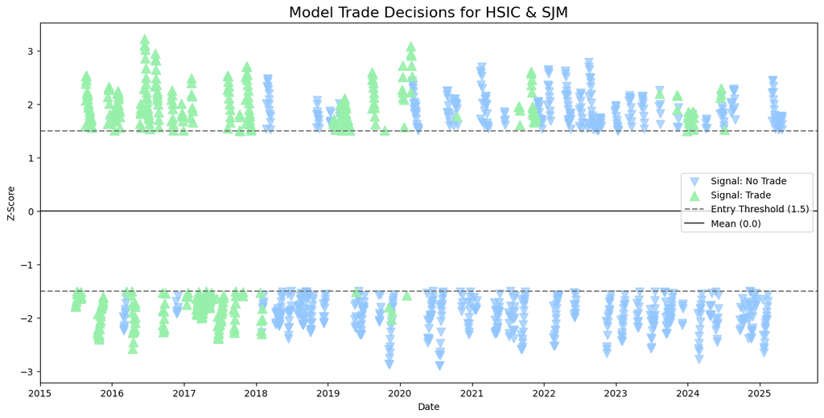

```python
from sklearn.model_selection import train_test_split
from sklearn.metrics import classification_report
from sklearn.linear_model import LogisticRegression

def decide_trade_with_logistic_regression(spread_df, features_df, ticker1, ticker2, trade_horizon=15):

    pair_atr = features_df.loc[(slice(None), [ticker1, ticker2]), 'atr'].unstack()
    avg_atr = pair_atr.mean(axis=1)
    model_data = spread_df.join(avg_atr.rename('atr'))
    model_data.dropna(inplace=True)


    z_scores = model_data['z_score']
    future_outcome = z_scores.rolling(window=trade_horizon).apply(lambda x: 1 if np.sign(x.iloc[0]) != np.sign(x.iloc[-1]) else 0, raw=False)

    #shift label back to align the future outcome with today's features.
    model_data['trade_outcome'] = future_outcome.shift(-trade_horizon)

    entry_condition = (model_data['z_score'] > 1.5) | (model_data['z_score'] < -1.5)
    final_df = model_data[entry_condition].copy()

    #Drop NaNs created by shifting the label. These are the most recent data points for which the future outcome is not yet known to prevent data leakage!
    final_df.dropna(subset=['trade_outcome'], inplace=True)
    final_df['trade_outcome'] = final_df['trade_outcome'].astype(int)

    if len(final_df) < 50:
        print("Not enough historical trading opportunities to build a reliable model.")
        return "Not enough data"

    #Model Training
    X = final_df[['z_score', 'atr']]
    Y = final_df['trade_outcome']

    #Now the split is properly aligned without creating lookahead bias, shuffle must be false to avoid another source of data leakage
    X_train, X_test, y_train, y_test = train_test_split(X, Y, test_size=0.3, random_state=10, shuffle=False)

    model = LogisticRegression(class_weight='balanced')
    model.fit(X_train, y_train)

    print("Model Evaluation on Test Data")
    predictions = model.predict(X_test)
    print(classification_report(y_test, predictions, zero_division=0))
    print("\n")

    #Make a Prediction for the most recent point
    last_point = X.iloc[[-1]]
    prediction = model.predict(last_point)[0]
    proba = model.predict_proba(last_point)[0][1]

    all_predictions = model.predict(X)
    final_df['model_decision'] = np.where(all_predictions == 1, 'Trade', 'No Trade')
    print(f"Signal for {last_point.index[0].date()}:")
    print(f"Z-Score: {last_point['z_score'].values[0]:.2f}, ATR: {last_point['atr'].values[0]:.4f}")
    print(f"Model's predicted probability of success for the most recent data point: {proba:.2%}")

    threshold = 0.6
    if prediction == 1 and proba > threshold:
        print(f"Probability over threshold: {threshold}, Decision: Enter Position!")
        return final_df
    else:
        print(f"Probability under threshold: {threshold}, Decision: Don't enter Position.")
        return final_df

trade_signal = decide_trade_with_logistic_regression(spread_analysis_df, technical_features, top_pair['Ticker 1'], top_pair['Ticker 2'], trade_horizon=15)

#Plots the z-score and overlays the model's trade decisions.
trade_signals = trade_signal[trade_signal['model_decision'] == 'Trade']
no_trade_signals = trade_signal[trade_signal['model_decision'] == 'No Trade']

plt.style.use('seaborn-v0_8-pastel')
fig, ax = plt.subplots(figsize=(15, 7))

#Plot the z-score entry opportunities and the model's decision
ax.scatter(no_trade_signals.index, no_trade_signals['z_score'],
            marker='v', label='Signal: No Trade', s=80, alpha=0.7)
ax.scatter(trade_signals.index, trade_signals['z_score'],
            marker='^', label='Signal: Trade', s=100, alpha=0.9)


ax.axhline(1.5, color='gray', linestyle='--', linewidth=1.5, label='Entry Threshold (1.5)')
ax.axhline(-1.5, color='gray', linestyle='--', linewidth=1.5)
ax.axhline(0, color='black', linestyle='-', linewidth=1.5, alpha=0.7, label='Mean (0.0)')

ax.set_title(f'Model Trade Decisions for {top_pair['Ticker 1']} & {top_pair['Ticker 2']}', fontsize=16)
ax.set_xlabel('Date', fontsize=10)
ax.set_ylabel('Z-Score', fontsize=10)
ax.legend()
plt.show()
```

We can see from this illustration data points where the spread meets the 1.5 zscore threshold to be considered for trading. Despite many points making the cutoff, the model opts not to enter a trade based on market volatility and magnitude of the z-score in many cases, particularly for negative z sores after 2019. The model will only signal to enter a trade when its calculated probability of success is atleast 60%, which means many potential z-score thresholds will not make the cut. Reviewing the precision and recall, our numbers are good in some areas but, overall, are quite unsatisfactory. For this reason, I'll try again with an ensemble model, random forest. I'll also incorporate an additional parameter, market beta, so the model can take the movement of the entire market into account.

```
> Random Forest Model Evaluation on Test Data <
              precision    recall  f1-score   support

           0       0.73      0.86      0.79       263
           1       0.46      0.27      0.34       115

    accuracy                           0.68       378
   macro avg       0.60      0.57      0.57       378
weighted avg       0.65      0.68      0.65       378



> Feature Importances <
         importance
atr        0.377398
z_score    0.320294
beta       0.302308


Signal for 2025-04-25:
Z-Score: 1.53, ATR: 2.6802, Beta: 0.42
Model's predicted probability of success for the final data point: 18.02%
Probability under threshold: 0.6, Don't enter Position.
```

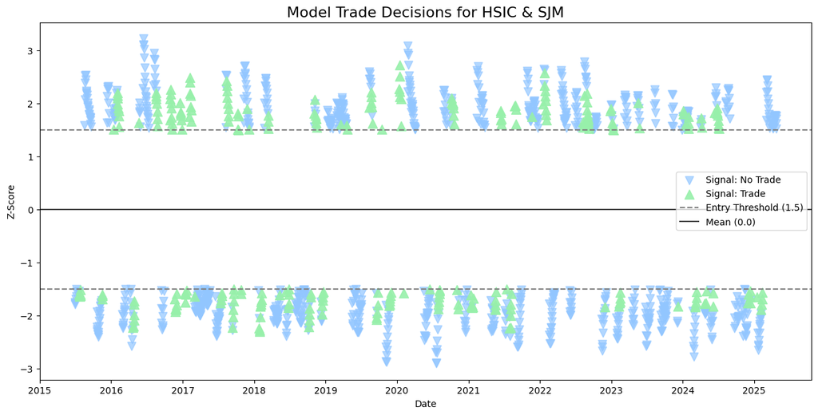

```python
from sklearn.ensemble import RandomForestClassifier

def decide_trade_with_random_forest(spread_df, features_df, ticker1, ticker2, trade_horizon=15):
    """
    Uses a Random Forest model with Z-Score, ATR, and Beta to classify a trading signal.
    """
    #find the features for the specific pair
    pair_atr = features_df.loc[(slice(None), [ticker1, ticker2]), 'atr'].unstack()
    pair_beta = features_df.loc[(slice(None), [ticker1, ticker2]), 'beta'].unstack()

    avg_atr = pair_atr.mean(axis=1)
    avg_beta = pair_beta.mean(axis=1)
    model_data = spread_df.join(avg_atr.rename('atr')).join(avg_beta.rename('beta'))
    model_data.dropna(inplace=True)


    z_scores = model_data['z_score']
    future_outcome = z_scores.rolling(window=trade_horizon).apply(lambda x: 1 if np.sign(x.iloc[0]) != np.sign(x.iloc[-1]) else 0, raw=False)

    #align the future outcome with today's features.
    model_data['trade_outcome'] = future_outcome.shift(-trade_horizon)

    entry_condition = (model_data['z_score'] > 1.5) | (model_data['z_score'] < -1.5)
    final_df = model_data[entry_condition].copy()

    #make sure to drop rows where the future outcome is not yet known.
    final_df.dropna(subset=['trade_outcome'], inplace=True)
    final_df['trade_outcome'] = final_df['trade_outcome'].astype(int)

    if len(final_df) < 50:
        print("Not enough historical trading opportunities to build a reliable model.")
        return "Not enough data"

    X = final_df[['z_score', 'atr', 'beta']]
    Y = final_df['trade_outcome']

    # Train and evaluate the model
    X_train, X_test, y_train, y_test = train_test_split(X.iloc[:-1], Y.iloc[:-1], test_size=0.3, random_state=20, shuffle=False)

    model = RandomForestClassifier(
        n_estimators=100,
        max_depth=10,           #Max depth of each tree to reduce overfitting
        random_state=20,
        class_weight='balanced'
    )
    model.fit(X_train, y_train)

    print("> Random Forest Model Evaluation on Test Data <")
    print(classification_report(y_test, model.predict(X_test), zero_division=0))
    print("\n")


    feature_importances = pd.DataFrame(model.feature_importances_, index=X.columns, columns=['importance']).sort_values('importance', ascending=False)
    print("> Feature Importances <")
    print(feature_importances)
    print("\n")

    #make a prediction for the most recent point
    last_point = X.iloc[[-1]]
    prediction = model.predict(last_point)[0]
    proba = model.predict_proba(last_point)[0][1]
    #return all predictions for model review
    all_predictions = model.predict(X)
    final_df['model_decision'] = np.where(all_predictions == 1, 'Trade', 'No Trade')

    print(f"Signal for {last_point.index[0].date()}:")
    print(f"Z-Score: {last_point['z_score'].values[0]:.2f}, ATR: {last_point['atr'].values[0]:.4f}, Beta: {last_point['beta'].values[0]:.2f}")
    print(f"Model's predicted probability of success for the final data point: {proba:.2%}")

    threshold = 0.6
    if prediction == 1 and proba > threshold:
        print(f"Probability over threshold: {threshold}, Enter Position!")
        return final_df
    else:
        print(f"Probability under threshold: {threshold}, Don't enter Position.")
        return final_df

trade_signal = decide_trade_with_random_forest(spread_analysis_df, technical_features, top_pair['Ticker 1'], top_pair['Ticker 2'])

#Plots the z-score and overlays the model's trade decisions.
trade_signals = trade_signal[trade_signal['model_decision'] == 'Trade']
no_trade_signals = trade_signal[trade_signal['model_decision'] == 'No Trade']

plt.style.use('seaborn-v0_8-pastel')
fig, ax = plt.subplots(figsize=(15, 7))

#Plot the z-score entry opportunities and the model's decision
ax.scatter(no_trade_signals.index, no_trade_signals['z_score'],
            marker='v', label='Signal: No Trade', s=80, alpha=0.7)
ax.scatter(trade_signals.index, trade_signals['z_score'],
            marker='^', label='Signal: Trade', s=100, alpha=0.9)

ax.axhline(1.5, color='gray', linestyle='--', linewidth=1.5, label='Entry Threshold (1.5)')
ax.axhline(-1.5, color='gray', linestyle='--', linewidth=1.5)
ax.axhline(0, color='black', linestyle='-', linewidth=1.5, alpha=0.7, label='Mean (0.0)')

ax.set_title(f'Model Trade Decisions for {top_pair['Ticker 1']} & {top_pair['Ticker 2']}', fontsize=16)
ax.set_xlabel('Date', fontsize=10)
ax.set_ylabel('Z-Score', fontsize=10)
ax.legend()
plt.show()
```

When comparing this plot to the logistic regression, we can see there is a much more discriminatory nature, with a more fine-toothed ability to pick when to trade compared to the regression. Our precision and recall have also improved modestly, although ultimately both models choose not to trade on the most recent data. We could expand this program to run on many pairs at once, allowing us to further hedge with a more diversified portfolio of different industrys. There is definitely promise in what has been built here, but additional testing on other market parameters would definitely be worthwhile. There is atleast one more caveat in that real world conditions have not been fully taken into account, especially transaction cost. The model would certainly need to undergo backtesting simulations with a realistic transaction cost taken into account. Lastly, its likely valuable to run some additional risk management techniques. Although our current method is using some tools like beta, we could also check other statistics like the Sharpe-Ratio or build in a stop loss if z-scores reach an excessive level. Lag between data collection and trading time might also need to be considered further. As a whole, this model is a good starting point for a quantitative trading strategy which utilizes a variety of market metrics and aims for statistically sound quantitative analysis.